# MikhailGroysmanHomework2_09082018

Mikhail Groysman

September 8, 2018

In this project, our surveyed population (in this porticular case all 6 are family members) rate 6 current movies on scale from 1 (lowest) to 5 (higest). 0 is assigned if person has not seen the movies. Our sample is very small, however we have everything set up so that if it is nessasary the project could be easily scaled up.

Steps:

1. MySQL DB created with 3 tables:
1. tblPeopel - it contains personal info (first name, last name, relationship, and so on)
2. tblMovies - movie name, year of release, and country of release
3. tblRating - rating by person and movie
2. 3 tables are combined into one table and the table is saved as csv file on local drive
3. Csv file loaded in R
4. Basic analysis is perfromed to see any indentifable trends
1. Our population has higher number of females than males (4 vs 2)
2. Age varies from 39 to 73; average is 55
3. Phone is the most popular way to conduct surveys (half were done over the phone)
4. if we include ratings for movies which has not been seen (rating of 0) than average rating is 2.75
5. We create subset of our data for only movies which were seen (rating is not 0; 23 observations)
1. Black Panther and Mission Impossible are the most popular movies each seen by 5 people
2. Anatoly appears to be vivid movie fan, he has seen all 6 movies; Luda has only seen 1
3. Average rating is 4.3
6. Building histogram of age distribution; two generational clusters 40-50’s and over 70
7. Scatterplot does not show clear correlation between Age and Rating
8. Boxplot indicate that movies got mostly positive reviews with rating 1 and 2 being outliers

```r
movies<-read.csv(file="c:/Dataflights/MoviesOut.csv", header=FALSE, sep=",")

movies
```

```
##    V1 V2                            V3                    V4   V5  V6 V7
## 1   1  1             Crazy Rich Asians            Jon M. Chu 2018 USA  1
## 2   2  2                      Oceans 8             Gary Ross 2018 USA  1
## 3   3  3        Avangers: Infinity War         Anthony Russo 2018 USA  1
## 4   4  4                    Deadpool 2           David Letch 2018 USA  1
## 5   5  5 Mission: Impossible - Fallout Christopher McQuarrie 2018 USA  1
## 6   6  6                 Black Panther          Rayn Coogler 2018 USA  1
## 7   7  1             Crazy Rich Asians            Jon M. Chu 2018 USA  2
## 8   8  2                      Oceans 8             Gary Ross 2018 USA  2
## 9   9  3        Avangers: Infinity War         Anthony Russo 2018 USA  2
## 10 10  4                    Deadpool 2           David Letch 2018 USA  2
## 11 11  5 Mission: Impossible - Fallout Christopher McQuarrie 2018 USA  2
## 12 12  6                 Black Panther          Rayn Coogler 2018 USA  2
## 13 13  1             Crazy Rich Asians            Jon M. Chu 2018 USA  3
## 14 14  2                      Oceans 8             Gary Ross 2018 USA  3
```

[output cut: 59 more lines]

```r
names(movies)<-c("Rate_id", "Movie_id", "MName", "Direcror", "RYear", "Country", "PersonID", "FName", "LName", "Relationship", "Gender", "Age", "SDate", "SMethod", "Rating" )

summary(movies)
```

```
##     Rate_id         Movie_id                             MName
##  Min.   : 1.00   Min.   :1.0   Avangers: Infinity War       :6
##  1st Qu.: 9.75   1st Qu.:2.0   Black Panther                :6
##  Median :18.50   Median :3.5   Crazy Rich Asians            :6
##  Mean   :18.50   Mean   :3.5   Deadpool 2                   :6
##  3rd Qu.:27.25   3rd Qu.:5.0   Mission: Impossible - Fallout:6
##  Max.   :36.00   Max.   :6.0   Oceans 8                     :6
##                   Direcror     RYear      Country     PersonID
##  Anthony Russo        :6   Min.   :2018   USA:36   Min.   :1.0
##  Christopher McQuarrie:6   1st Qu.:2018            1st Qu.:2.0
##  David Letch          :6   Median :2018            Median :3.5
##  Gary Ross            :6   Mean   :2018            Mean   :3.5
##  Jon M. Chu           :6   3rd Qu.:2018            3rd Qu.:5.0
##  Rayn Coogler         :6   Max.   :2018            Max.   :6.0
##      FName           LName            Relationship Gender      Age
##  Alex   :6   Groyman    : 6   Brother-in-law: 6    F:24   Min.   :39.00
##  Anatoly:6   Groysman   :12   Father        : 6    M:12   1st Qu.:45.00
##  Anna   :6   Petrikovsky: 6   Mother        : 6           Median :49.50
##  Galina :6   Smirnova   : 6   Sister        :12           Mean   :54.67
##  Luda   :6   Sunwoo     : 6   Wife          : 6           3rd Qu.:72.00
##  Ok     :6                                                Max.   :73.00
##         SDate         SMethod       Rating
##  2018-09-07:18   Email    : 6   Min.   :0.00
##  2018-09-08:18   In person: 6   1st Qu.:0.00
##                  Phone    :18   Median :4.00
##                  Texting  : 6   Mean   :2.75
##                                 3rd Qu.:5.00
##                                 Max.   :5.00
```

```r
moviesNo0<-subset(movies,movies$Rating>0)

summary(moviesNo0)
```

```
##     Rate_id        Movie_id                               MName
##  Min.   : 1.0   Min.   :1.000   Avangers: Infinity War       :3
##  1st Qu.:15.5   1st Qu.:2.000   Black Panther                :5
##  Median :24.0   Median :4.000   Crazy Rich Asians            :3
##  Mean   :22.3   Mean   :3.783   Deadpool 2                   :3
##  3rd Qu.:30.5   3rd Qu.:5.000   Mission: Impossible - Fallout:5
##  Max.   :36.0   Max.   :6.000   Oceans 8                     :4
##                   Direcror     RYear      Country     PersonID
##  Anthony Russo        :3   Min.   :2018   USA:23   Min.   :1.000
##  Christopher McQuarrie:5   1st Qu.:2018            1st Qu.:3.000
##  David Letch          :3   Median :2018            Median :4.000
##  Gary Ross            :4   Mean   :2018            Mean   :4.087
##  Jon M. Chu           :3   3rd Qu.:2018            3rd Qu.:5.500
##  Rayn Coogler         :5   Max.   :2018            Max.   :6.000
##      FName           LName           Relationship Gender      Age
##  Alex   :3   Groyman    :4   Brother-in-law:6     F:14   Min.   :39.00
##  Anatoly:6   Groysman   :8   Father        :3     M: 9   1st Qu.:45.00
##  Anna   :4   Petrikovsky:6   Mother        :1            Median :47.00
##  Galina :5   Smirnova   :1   Sister        :9            Mean   :50.61
##  Luda   :1   Sunwoo     :4   Wife          :4            3rd Qu.:52.00
##  Ok     :4                                               Max.   :73.00
##         SDate         SMethod      Rating
##  2018-09-07: 8   Email    :4   Min.   :1.000
##  2018-09-08:15   In person:4   1st Qu.:4.000
##                  Phone    :9   Median :5.000
##                  Texting  :6   Mean   :4.304
##                                3rd Qu.:5.000
##                                Max.   :5.000
```

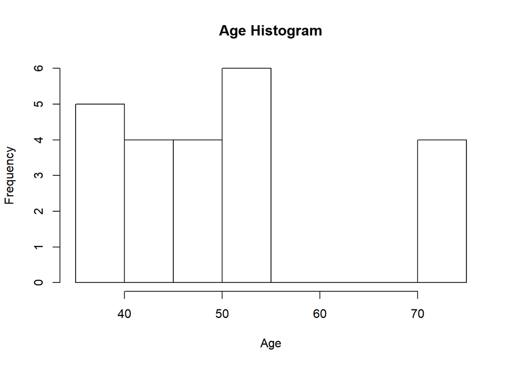

```r
hist(moviesNo0$Age, main="Age Histogram", xlab="Age")
```

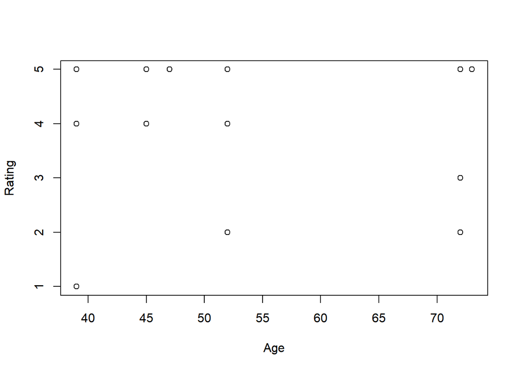

```r
plot(Rating~Age, data=moviesNo0)
```

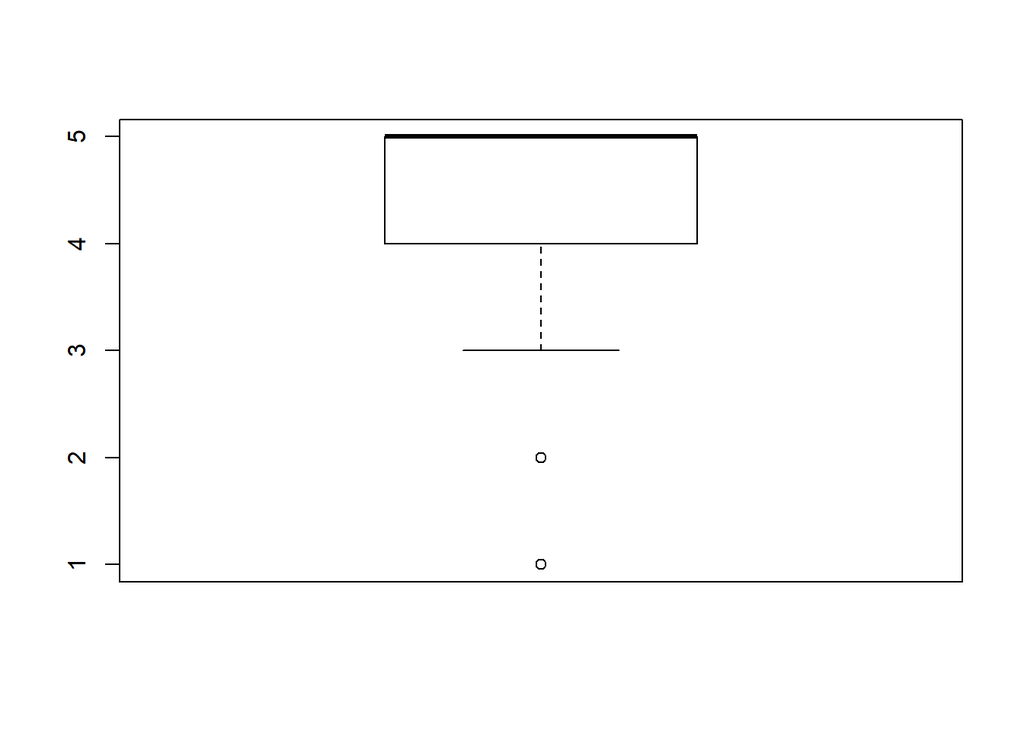

```r
boxplot(moviesNo0$Rating)
```